# Diagnósticos no Espaço de Embeddings

Prof. Cesar Henrique Comin

## O que os hashes não identificam

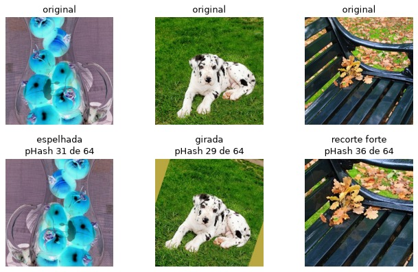

- Hashes perceptuais em geral tratam esses pares como imagens **sem relação nenhuma**.
- Para achar esses casos é preciso comparar **o que está na foto**, e não onde os pixels estão.

## Embedding de imagens

- O pHash transforma cada imagem numa lista de 64 números, e a distância entre duas listas é uma medida de similaridade. Isso já é uma forma de **embedding**, mas raramente é chamado assim.
- A regra que produz esses 64 bits foi **escrita à mão**: reduza para 8 por 8, converta para cinza, compare cada valor com a média.
- Usaremos outro tipo de embedding, produzido de forma automática por uma rede neural.
- Chamados de **embeddings semânticos**.

## Embedding de imagens

- O modelo DINOv3, uma rede neural, foi treinado para calcular a similaridade entre **1.7 bilhões de imagens**.
- Para cada imagem, ele gera um vetor de 384 valores, ou seja um ponto num espaço de 384 dimensões.
- Os valores não possuem significado facilmente interpretável.
- Importa apenas a **posição relativa**: Imagens com vetores próximos entre si tendem a ser imagens que uma pessoa chamaria de parecidas.
- A proximidade é calculada através da similaridade de cosseno.

## Valores de similaridade

- Distribuição da similaridade coseno entre as imagens do dataset:

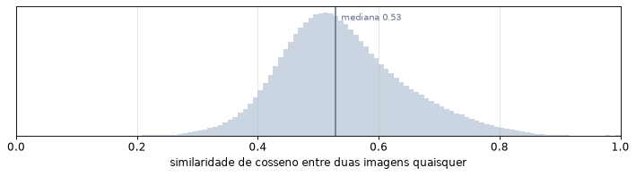

- Duas fotos sem relação nenhuma não dão similaridade zero, dão cerca de **0,53**.

## Exemplos

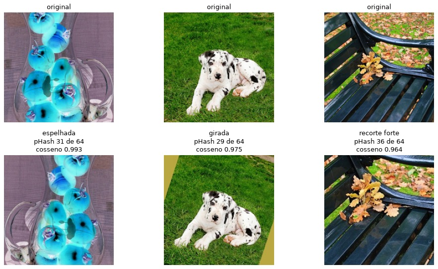

# Quase-duplicatas semânticas

## Detecção de duplicatas usando DINO

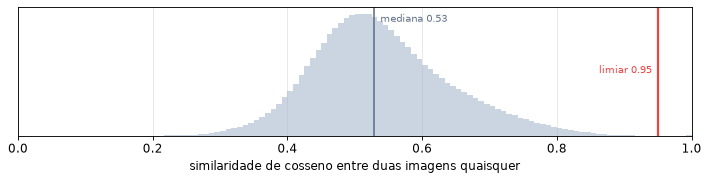

```
pares com cosseno >= 0.95 ....... 167
  destes, cópias de verdade ..... 142
  precisão ...................... 0.85
  revocação ..................... 0.86
```

| método | precisão | revocação |
| --- | --- | --- |
| pHash, limiar 10 bits | 0,86 | 0,72 |
| cosseno, limiar 0,95 | 0,85 | **0,86** |

## Precisão vs revocação

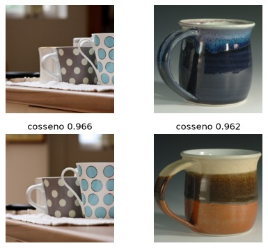

- A revocação subiu de 0,72 para 0,86, mas a precisão **não melhorou**
- Embeddings são robustos a transformações geométricas, mas podem perder precisão porque “semanticamente quase idêntico” também inclui fotos **diferentes** do mesmo objeto.

# Imagens outliers

## Imagens outliers

- Imagens que não se parecem com nenhuma outra do conjunto em geral são **outliers**.
- Um escore popular é a distância até a `k`-ésima imagem vizinha mais próxima.
- Uma caneca no meio de outras 200 canecas tem raio pequeno. Uma imagem de ruído, que não se parece com nada, tem raio enorme.
- Reportamos sempre em **percentil**, porque o valor bruto não tem unidade interpretável.

## Aplicação no dataset

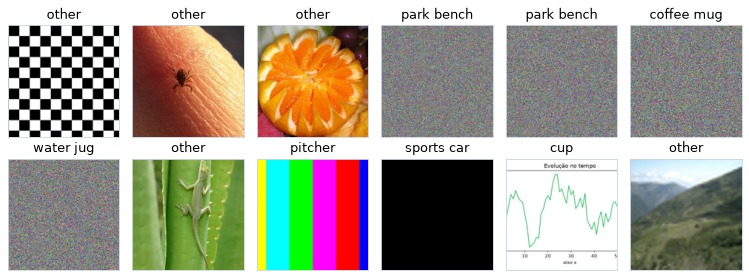

## O `k` decide a sensitividade

- Podem haver diferentes imagens outliers parecidas. Exemplo: cinco imagens em branco.
- Com `k` pequeno, cada imagem tem vizinhos bem próximos, e o escore de outlier é baixo.
- **Um grupo de anomalias só aparece quando o `k` passa do tamanho do grupo.** Na prática, o `k` precisa ser maior que o maior grupo de outliers que você espera encontrar.

# Agrupamento e mapas

## Agrupar sem rótulo

- Embeddings permitem agrupar imagens **sem usar rótulos**.
- Resultado do k-means executado com `k=9` clusters:

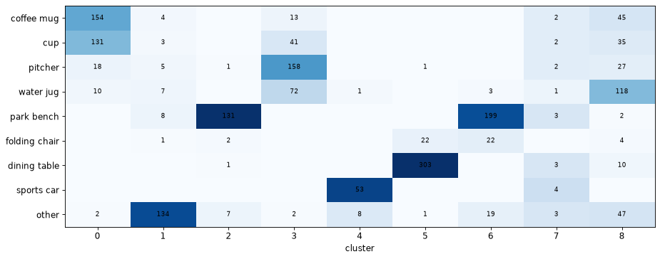

## Agrupar sem rótulo

- Resultados interessantes do k-means:
  1. `park bench` e `water jug` se dividem em dois clusters
  2. `folding chair` não ganha cluster próprio, e se dissolve entre `dining table` e `park bench`
  3. O cluster 7 não se associa claramente com nenhum rótulo conhecido. Provavelmente é formado por imagens que não se parecem com nada do conjunto.

## Mapas em duas dimensões

- Os métodos de redução de dimensionalidade tentam **projetar** os pontos de 384 dimensões em 2 dimensões.
- O **PCA** é um método muito popular porque é linear, interpretável e rápido. Ele raramente cria separações que não existem no espaço original.
- O **UMAP** é um método mais recente, não linear, que preserva vizinhança. Ele pode criar separações que não existem no espaço original, mas costuma ser mais útil para visualizar dados de alta dimensão.

## Mapas em duas dimensões

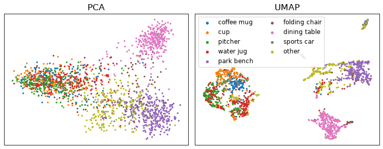

## Muito cuidado com o UMAP

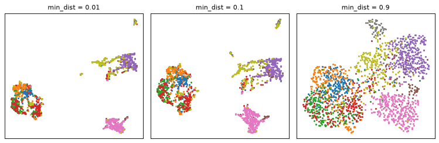

## Muito cuidado com o UMAP

- Os grupos gerados pelo UMAP podem variar bastante de acordo com os parâmetros do método.
- A **distância entre dois grupos** não possui significado, e o **tamanho de um grupo** também não.
- O mapa serve para **levantar hipótese e escolher o que investigar**, e não para gerar conclusões.

# Uso de embeddings para anotação de imagens

## O problema do orçamento

- Anotar 1845 imagens custa caro, e esse é o gargalo real da maioria dos projetos.
- Se der para anotar **60**, quais 60?
- Uma possibilidade é escolher um **coreset**, um subconjunto que cubra o espaço
- Uma estratégia simples e popuplar: comece por uma imagem qualquer e, a cada passo, pegue a que está **mais longe de tudo que já foi escolhido**.
- Uma variante é rodar o mesmo algoritmo **dentro de cada cluster** identificado por um método de clusterização.

## Seleção de coreset

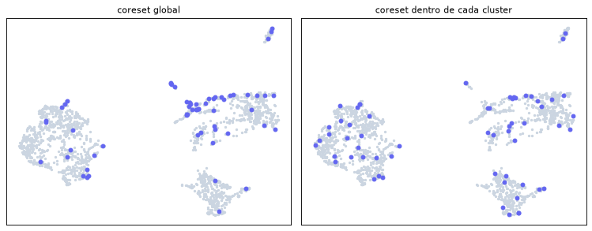

- O coreset global cobre o espaço melhor, mas tende a focar nas **bordas** e em outliers.

## Assuntos adicionais

- Existem outros extratores, como o **CLIP** e o **SigLIP**, treinados com pares de imagem e texto. Eles permitem calcular a similaridade entre imagens e texto.
- Em datasets com milhões de imagens, a matriz de similaridade não cabe na memória, e a busca passa a usar índices de vizinhança aproximada, como nas bibliotecas Python `faiss` e `hnswlib`.